# **Loan Default Prediction**

## **Problem Definition**

### **The Context:**

- Given that a significant portion of bank profits comes from home loan interest, it’s crucial for banks to approve loans judiciously to avoid losses from defaulters. The traditional approval process is time-consuming and often influenced by human biases, which can result in incorrect decisions—either approving high-risk clients or rejecting creditworthy ones. Automating this process is essential not only for accurately predicting defaulters but also for retaining good customers who, if treated unfairly, could lead to further losses. Automation would also reduce costs by streamlining the process and making it more efficient

### **The objective:**

- Build a classification model to predict clients who are likely to default on their loans and provide recommendations to the bank on the key features to consider when approving a loan.

### **The key questions:**

- What factors influence loan defaults?
- What is the historical default rate for the bank?
- Is the dataset biased towards non-defaulters, and how will this affect model performance?
- Can we identify the key features that significantly influence the likelihood of default?
- What is the optimal threshold for predicting a defaulter? (Should the model prioritize minimizing false positives (good clients labeled as defaulters) or false negatives (risky clients labeled as safe)?)
- What recommendations can be derived from the model to help the bank approve loans more judiciously?

### **The problem formulation**:

- The problem we are trying to solve is to predict which clients are likely to default on their loans by building a data-driven model that can assess a client's creditworthiness. The goal is to help banks make more informed, efficient, and objective loan approval decisions, minimizing default risk while maintaining profitability and customer satisfaction.
- This is a supervised classification problem, where we aim to: Classify clients as likely or unlikely to default based on historical data. Train the model on labeled data (past loans with outcomes) and use it to predict the probability of default for new applicants.

## **Data Description:**

The Home Equity dataset (HMEQ) contains baseline and loan performance information for 5,960 recent home equity loans. The target (BAD) is a binary variable that indicates whether an applicant has ultimately defaulted or has been severely delinquent. This adverse outcome occurred in 1,189 cases (20 percent). 12 input variables were registered for each applicant.

- **BAD:** 1 = Client defaulted on loan, 0 = loan repaid
- **LOAN:** Amount of loan approved.
- **MORTDUE:** Amount due on the existing mortgage.
- **VALUE:** Current value of the property.
- **REASON:** Reason for the loan request. (HomeImp = home improvement, DebtCon= debt consolidation which means taking out a new loan to pay off other liabilities and consumer debts)
- **JOB:** The type of job that loan applicant has such as manager, self, etc.
- **YOJ:** Years at present job.
- **DEROG:** Number of major derogatory reports (which indicates a serious delinquency or late payments).
- **DELINQ:** Number of delinquent credit lines (a line of credit becomes delinquent when a borrower does not make the minimum required payments 30 to 60 days past the day on which the payments were due).
- **CLAGE:** Age of the oldest credit line in months.
- **NINQ:** Number of recent credit inquiries.
- **CLNO:** Number of existing credit lines.
- **DEBTINC:** Debt-to-income ratio (all your monthly debt payments divided by your gross monthly income. This number is one way lenders measure your ability to manage the monthly payments to repay the money you plan to borrow.

## **Import the necessary libraries and Data**

```python
import pandas as pd
import numpy as np
import matplotlib.pyplot as plt
import seaborn as sns

import warnings
warnings.filterwarnings("ignore")

# Removes the limit for the number of displayed columns
pd.set_option("display.max_columns", None)

# Sets the limit for the number of displayed rows
pd.set_option("display.max_rows", 200)

# To build models for prediction
from sklearn.model_selection import train_test_split, cross_val_score, KFold
from sklearn.linear_model import LinearRegression, Ridge, Lasso, ElasticNet
from sklearn.tree import DecisionTreeRegressor
from sklearn.ensemble import RandomForestRegressor,BaggingRegressor
from sklearn.preprocessing import StandardScaler
from sklearn.decomposition import PCA
from sklearn.cluster import DBSCAN
from sklearn.manifold import TSNE
from sklearn.neighbors import NearestNeighbors

# To encode categorical variables
from sklearn.preprocessing import LabelEncoder

# For tuning the model
from sklearn.model_selection import GridSearchCV

# To check model performance
from sklearn.metrics import make_scorer,mean_squared_error, r2_score, mean_absolute_error

import pandas as pd

import numpy as np

import matplotlib.pyplot as plt

import seaborn as sns

# To scale the data using z-score
from sklearn.preprocessing import StandardScaler

from sklearn.model_selection import train_test_split

# Algorithms to use
from sklearn import tree

from sklearn.tree import DecisionTreeClassifier

from sklearn.ensemble import RandomForestClassifier

# Metrics to evaluate the model
from sklearn import metrics

from sklearn.metrics import confusion_matrix, classification_report,recall_score,precision_score, accuracy_score

# For tuning the model
from sklearn.model_selection import GridSearchCV

# To ignore warnings
import warnings
warnings.filterwarnings("ignore")
from sklearn.linear_model import LogisticRegression
```

```python
#Mount Drive#
from google.colab import drive
drive.mount('/content/drive')
```

```python
# Read the Extra Learn File#
data = pd.read_csv("/content/drive/MyDrive/Python Course/hmeq.csv")
```

## **Data Overview**

- Reading the dataset
- Understanding the shape of the dataset
- Checking the data types
- Checking for missing values
- Checking for duplicated values

```python
# View the first 5 rows of the dataset
data.head()
```

|  | BAD | LOAN | MORTDUE | VALUE | REASON | JOB | YOJ | DEROG | DELINQ | CLAGE | NINQ | CLNO | DEBTINC |
| --- | --- | --- | --- | --- | --- | --- | --- | --- | --- | --- | --- | --- | --- |
| 0 | 1 | 1100 | 25860.0 | 39025.0 | HomeImp | Other | 10.5 | 0.0 | 0.0 | 94.366667 | 1.0 | 9.0 | NaN |
| 1 | 1 | 1300 | 70053.0 | 68400.0 | HomeImp | Other | 7.0 | 0.0 | 2.0 | 121.833333 | 0.0 | 14.0 | NaN |
| 2 | 1 | 1500 | 13500.0 | 16700.0 | HomeImp | Other | 4.0 | 0.0 | 0.0 | 149.466667 | 1.0 | 10.0 | NaN |
| 3 | 1 | 1500 | NaN | NaN | NaN | NaN | NaN | NaN | NaN | NaN | NaN | NaN | NaN |
| 4 | 0 | 1700 | 97800.0 | 112000.0 | HomeImp | Office | 3.0 | 0.0 | 0.0 | 93.333333 | 0.0 | 14.0 | NaN |

```python
# Understand the shape of the data
data.shape
```

```
(5960, 13)
```

```python
# Checking the info of the data
data.info()
```

```
<class 'pandas.core.frame.DataFrame'>
RangeIndex: 5960 entries, 0 to 5959
Data columns (total 13 columns):
 #   Column   Non-Null Count  Dtype
---  ------   --------------  -----
 0   BAD      5960 non-null   int64
 1   LOAN     5960 non-null   int64
 2   MORTDUE  5442 non-null   float64
 3   VALUE    5848 non-null   float64
 4   REASON   5708 non-null   object
 5   JOB      5681 non-null   object
 6   YOJ      5445 non-null   float64
 7   DEROG    5252 non-null   float64
 8   DELINQ   5380 non-null   float64
 9   CLAGE    5652 non-null   float64
 10  NINQ     5450 non-null   float64
 11  CLNO     5738 non-null   float64
 12  DEBTINC  4693 non-null   float64
dtypes: float64(9), int64(2), object(2)
memory usage: 605.4+ KB
```

Observations:

```python
# Checking for duplicate values in the data
data.duplicated().sum()
```

```
0
```

```python
#Convert the Status Column into Converted, Lost#
data['BAD'] = data['BAD'].map({1: 'DEFAULTED', 0: 'REPAID'})
```

## Summary Statistics

```python
# Checking the descriptive statistics of the columns
data.describe().T
```

|  | count | mean | std | min | 25% | 50% | 75% | max |
| --- | --- | --- | --- | --- | --- | --- | --- | --- |
| LOAN | 5960.0 | 18607.969799 | 11207.480417 | 1100.000000 | 11100.000000 | 16300.000000 | 23300.000000 | 89900.000000 |
| MORTDUE | 5442.0 | 73760.817200 | 44457.609458 | 2063.000000 | 46276.000000 | 65019.000000 | 91488.000000 | 399550.000000 |
| VALUE | 5848.0 | 101776.048741 | 57385.775334 | 8000.000000 | 66075.500000 | 89235.500000 | 119824.250000 | 855909.000000 |
| YOJ | 5445.0 | 8.922268 | 7.573982 | 0.000000 | 3.000000 | 7.000000 | 13.000000 | 41.000000 |
| DEROG | 5252.0 | 0.254570 | 0.846047 | 0.000000 | 0.000000 | 0.000000 | 0.000000 | 10.000000 |
| DELINQ | 5380.0 | 0.449442 | 1.127266 | 0.000000 | 0.000000 | 0.000000 | 0.000000 | 15.000000 |
| CLAGE | 5652.0 | 179.766275 | 85.810092 | 0.000000 | 115.116702 | 173.466667 | 231.562278 | 1168.233561 |
| NINQ | 5450.0 | 1.186055 | 1.728675 | 0.000000 | 0.000000 | 1.000000 | 2.000000 | 17.000000 |
| CLNO | 5738.0 | 21.296096 | 10.138933 | 0.000000 | 15.000000 | 20.000000 | 26.000000 | 71.000000 |
| DEBTINC | 4693.0 | 33.779915 | 8.601746 | 0.524499 | 29.140031 | 34.818262 | 39.003141 | 203.312149 |

LOAN:

The average loan amount is 18,607.97 with a wide standard deviation of 11,207.48, indicating considerable variation in loan amounts. The range is quite large, with the minimum loan at 1,100 and the maximum at 89,900, indicating the presence of loans of varying sizes. The 25th percentile (11,100), 50th percentile (16,300), and 75th percentile (23,300) show a moderate concentration in the middle values.

MORTDUE (Mortgage Due):

VALUE (Property Value):

The average property value is 101,776.05, with a large standard deviation of 57,385.78. The minimum value is 8,000, and the maximum is 855,909, indicating a broad range in property values. The 25th percentile (66,075.50) and 75th percentile (119,824.25) suggest most properties fall within this middle range, but the max value shows outliers or high-value properties.

YOJ (Years on Job):

The average years on the job is 8.92, with a standard deviation of 7.57. The minimum is 0 (likely people who recently started or have no job), while the maximum is 41 years. The 25th percentile (3 years) and 75th percentile (13 years) suggest that many people have moderate job tenure, though some outliers exist.

DEROG (Number of major derogatory reports):

The average number of derogatory reports is 0.25, with a standard deviation of 0.85. The majority of the data seems to be concentrated at 0 (as the 25th, 50th, and 75th percentiles are all 0), with a few extreme cases going up to 10 derogatory reports.

DELINQ (Number of delinquent credit lines):

The average number of delinquent lines is 0.45, with a standard deviation of 1.13. The majority of people have 0 delinquencies (as all quartiles show 0), but there are some extreme cases with delinquencies as high as 15.

CLAGE (Age of the oldest credit line in months):

The average age of the oldest credit line is 179.77 months (approximately 15 years), with a standard deviation of 85.81 months (about 7 years). The minimum value is 0 (likely for new credit holders), and the maximum is 1168.23 months (~97 years), showing the presence of very old credit lines.

NINQ (Number of recent credit inquiries):

The average number of inquiries is 1.19, with a standard deviation of 1.73. The minimum is 0, while the maximum is 17, indicating a few people have a large number of credit inquiries. The 25th percentile (0) and 75th percentile (2) show that most people have a small number of inquiries.

CLNO (Number of credit lines):

The average number of credit lines is 21.30, with a standard deviation of 10.14. The minimum is 0, and the maximum is 71, showing a wide variation in the number of credit lines. The 25th percentile (15) and 75th percentile (26) suggest that most people have between 15 and 26 credit lines.

DEBTINC (Debt-to-income ratio):

The average debt-to-income ratio is 33.78, with a standard deviation of 8.60. The minimum is 0.52 (likely a low-income individual with some debt), while the maximum is 203.31, which is an extreme outlier. The 25th percentile (29.14) and 75th percentile (39.00) suggest most people fall in this mid-range for debt-to-income ratio.

Overall Observations:

There are significant variations in loan amounts, mortgage dues, and property values, with some extreme outliers in each category. Most individuals have little to no derogatory reports, delinquencies, or recent credit inquiries, but a few outliers have very high values. The debt-to-income ratio shows a generally healthy range for most people, but with some extreme cases at the higher end.

```python
# List of all important categorical variables
cat_col = ["BAD", "REASON", 'JOB']

# Printing the number of occurrences of each unique value in each categorical column
for column in cat_col:
    print(data[column].value_counts(1))
    print("-" * 50)
```

```
BAD
REPAID       0.800503
DEFAULTED    0.199497
Name: proportion, dtype: float64
--------------------------------------------------
REASON
DebtCon    0.688157
HomeImp    0.311843
Name: proportion, dtype: float64
--------------------------------------------------
JOB
Other      0.420349
ProfExe    0.224608
Office     0.166872
Mgr        0.135011
Self       0.033973
Sales      0.019187
Name: proportion, dtype: float64
--------------------------------------------------
```

Key Insights:

## **Exploratory Data Analysis (EDA) and Visualization**

- EDA is an important part of any project involving data.
- It is important to investigate and understand the data better before building a model with it.
- A few questions have been mentioned below which will help you approach the analysis in the right manner and generate insights from the data.
- A thorough analysis of the data, in addition to the questions mentioned below, should be done.

**Leading Questions**:

1. What is the range of values for the loan amount variable "LOAN"?
2. How does the distribution of years at present job "YOJ" vary across the dataset?
3. How many unique categories are there in the REASON variable?
4. What is the most common category in the JOB variable?
5. Is there a relationship between the REASON variable and the proportion of applicants who defaulted on their loan?
6. Do applicants who default have a significantly different loan amount compared to those who repay their loan?
7. Is there a correlation between the value of the property and the loan default rate?
8. Do applicants who default have a significantly different mortgage amount compared to those who repay their loan?

### **Univariate Analysis**

```python
# Function to plot a boxplot and a histogram along the same scale

def histogram_boxplot(data, feature, figsize = (12, 7), kde = True, bins = 50):
    """
    Boxplot and histogram combined

    data: dataframe
    feature: dataframe column
    figsize: size of figure (default (12,7))
    kde: whether to show density curve (default False)
    bins: number of bins for histogram (default None)
    """
    f2, (ax_box2, ax_hist2) = plt.subplots(
        nrows = 2,      # Number of rows of the subplot grid = 2
        sharex = True,  # x-axis will be shared among all subplots
        gridspec_kw = {"height_ratios": (0.25, 0.75)},
        figsize = figsize,
    )                   # Creating the 2 subplots
    sns.boxplot(
        data = data, x = feature, ax = ax_box2, showmeans = True, color = "violet"
    )                   # Boxplot will be created and a star will indicate the mean value of the column
    sns.histplot(
        data = data, x = feature, kde = kde, ax = ax_hist2, bins = bins, palette = "winter"
    ) if bins else sns.histplot(
        data = data, x = feature, kde = kde, ax = ax_hist2
    )                   # For histogram
    ax_hist2.axvline(
        data[feature].mean(), color = "green", linestyle = "--"
    )                   # Add mean to the histogram
    ax_hist2.axvline(
        data[feature].median(), color = "black", linestyle = "-"
    )                   # Add median to the histogram
```

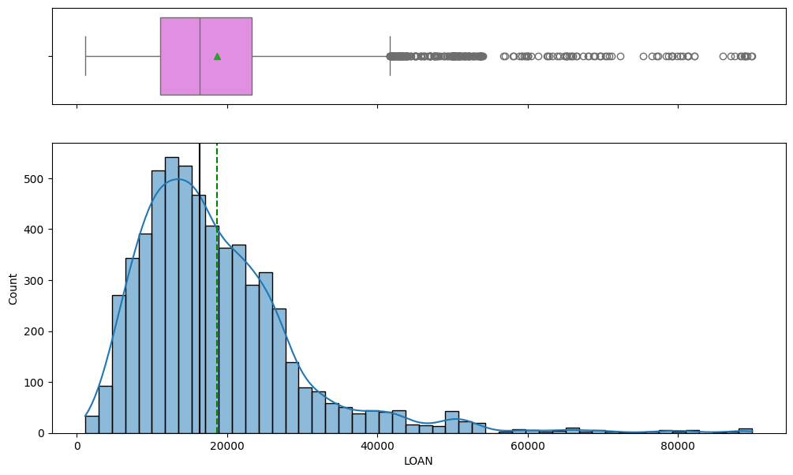

```python
#Check Numerical Variables Distribution#
histogram_boxplot(data, "LOAN")
```

The loan amount distribution is right-skewed, meaning there are outliers or extreme values at the higher end of the spectrum. This results in the mean being greater than the median, indicating that most loan amounts are concentrated at lower values, while a few large loans pull the average upward.

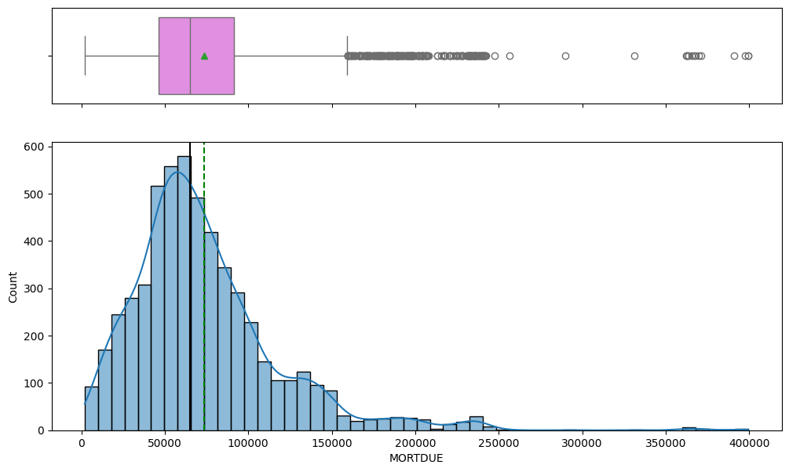

```python
histogram_boxplot(data, "MORTDUE")
```

The MORTDUE amount distribution is right-skewed, indicating that there are outliers or extreme values at the higher end. As a result, the mean is greater than the median, showing that most mortgage amounts are concentrated at lower values, while a few larger amounts pull the average upward. This pattern is expected, as higher mortgage values typically reflect greater debt capacity, suggesting that individuals with larger loans may have higher financial standing or access to more credit.

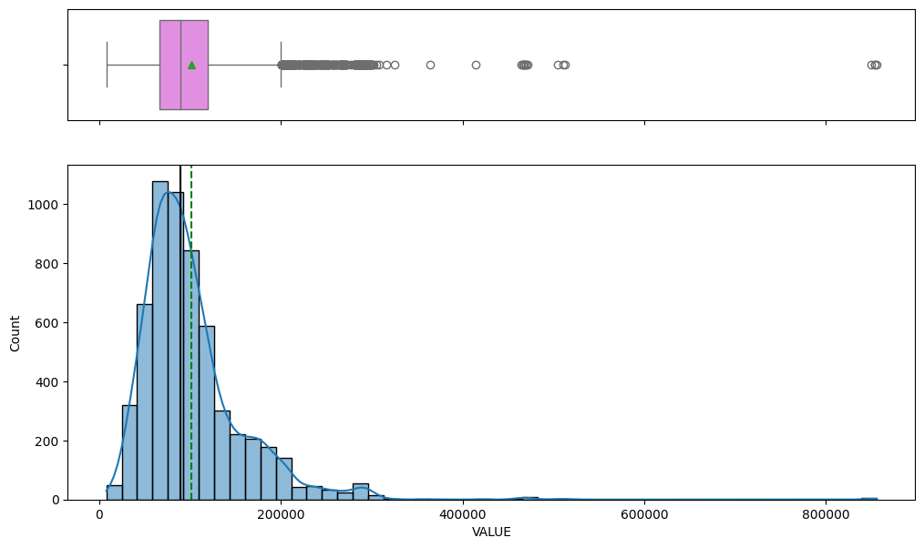

```python
histogram_boxplot(data, "VALUE")
```

The outliers or extreme values at the higher end of the property value distribution result in the mean being greater than the median, indicating that most property values are concentrated at lower amounts, while a few high-value properties pull the average upward. This is expected, as higher property values generally reflect greater debt capacity, suggesting that individuals with more expensive properties likely have higher financial standing or access to larger loans or credit.

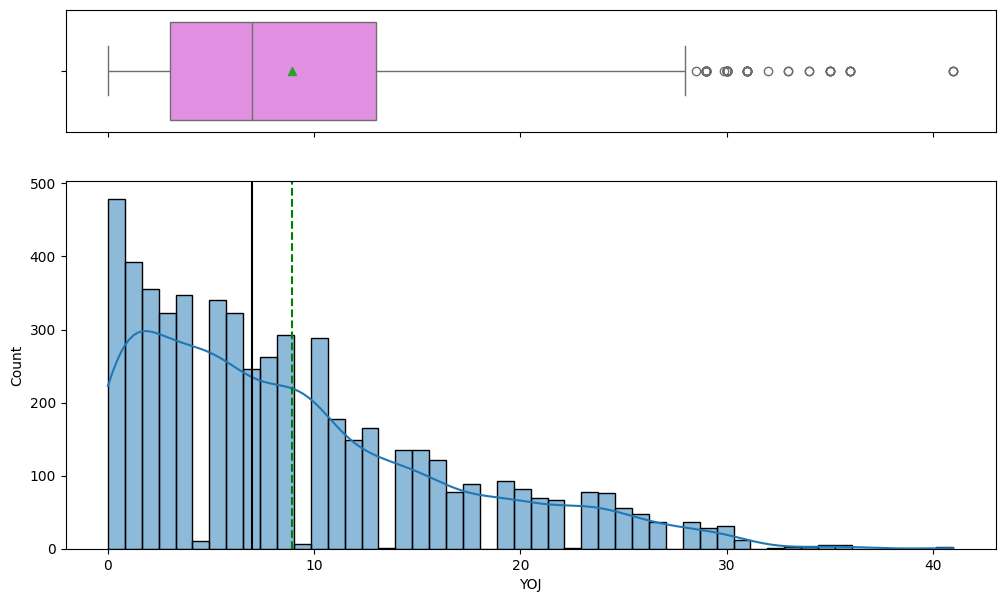

```python
histogram_boxplot(data, "YOJ")
```

The graph shows a high concentration of data for Years on the Job (YOJ) within less than 10 years, with a smaller number of values extending above 20 years. This suggests that most individuals have relatively short job tenures, while a few have significantly longer ones.

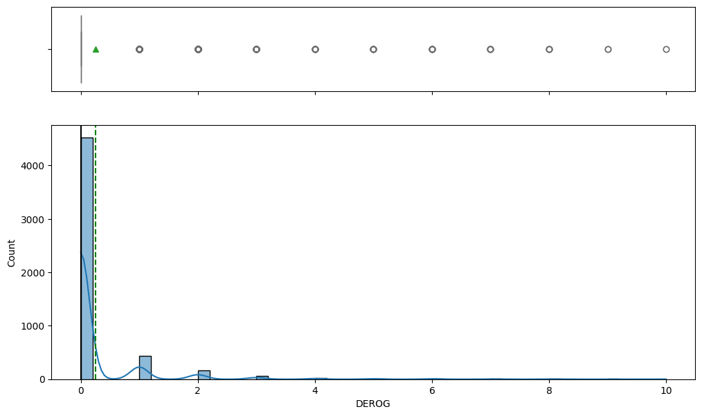

```python
histogram_boxplot(data, "DEROG")
```

The graph shows a high concentration of zero values for DEROG reports, which is expected since 80% of loans are typically repaid. This indicates that individuals with derogatory reports are relatively few compared to the total number of loan applicants, highlighting that most borrowers do not have major derogatory marks on their credit.

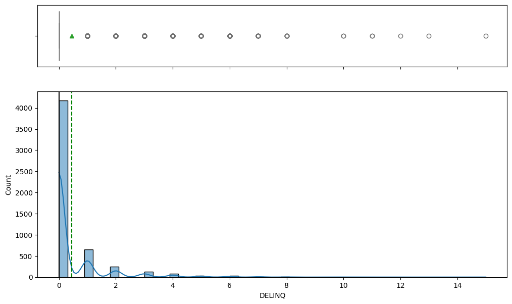

```python
histogram_boxplot(data, "DELINQ")
```

The graph shows a high concentration of zero values for DELINQ reports, which aligns with the fact that 80% of loans are typically repaid. This is expected, as low delinquency rates often correlate with the low occurrence of derogatory reports, suggesting a potential relationship between low derogatory and delinquency records, both contributing to higher loan repayment rates.

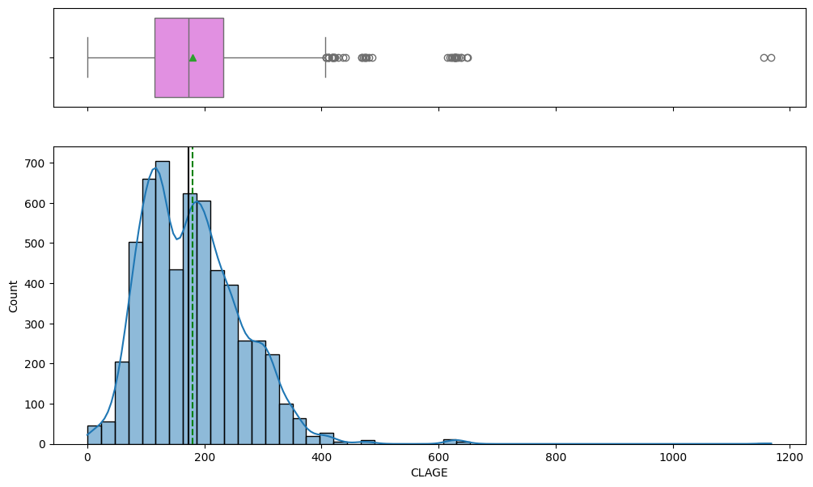

```python
histogram_boxplot(data, "CLAGE")
```

The CLAGE distribution appears to be normally distributed with a slight right skewness. However, some values exceeding 70 years should likely be removed, as they may not be logically valid—potentially representing deceased individuals who never repaid their debts. This adjustment could help ensure the data reflects more accurate and relevant age distributions for credit lines.

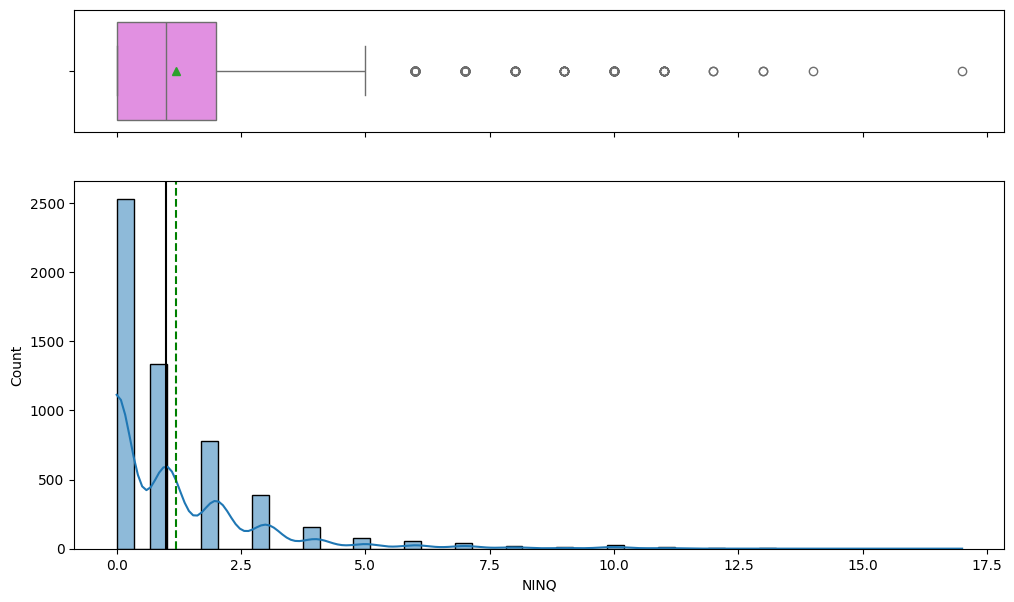

```python
histogram_boxplot(data, "NINQ")
```

The number of recent credit inquiries shows a high concentration at 0, with the mean being close to 1. This is expected, as most individuals are unlikely to request additional credit if they already have an existing loan. Consequently, the majority of people tend to maintain a low number of recent inquiries, reflecting cautious credit behavior.

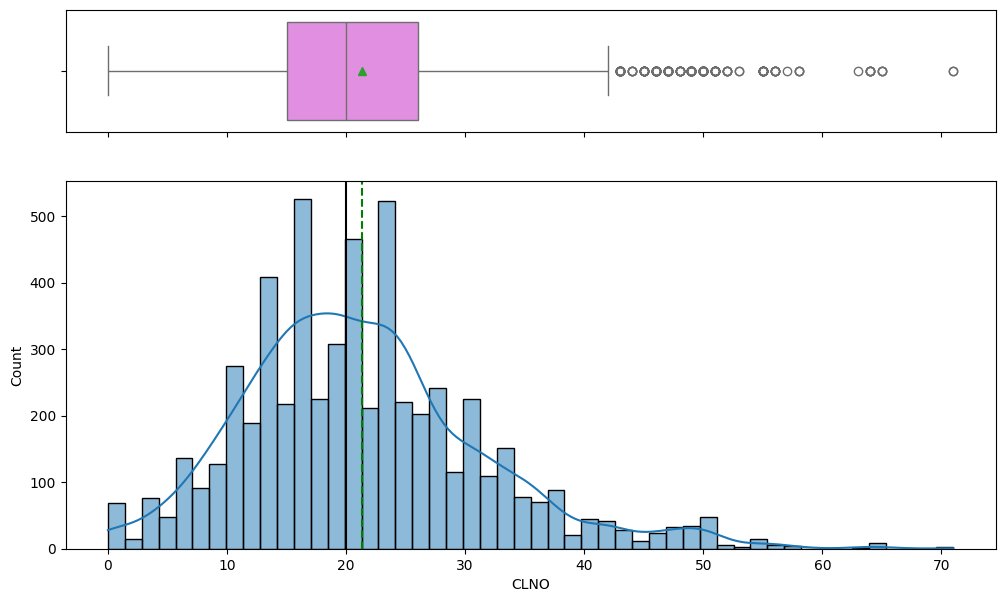

```python
histogram_boxplot(data, "CLNO")
```

The CLNO distribution shows a slightly right-skewed normal distribution. Most applicants appear to have considerable credit experience, as indicated by the number of credit lines. A few applicants exceed 50 CLNO, which is expected, as individuals with more extensive credit experience are likely to have a higher number of credit lines. This reflects their ability to manage multiple accounts, suggesting a greater familiarity with credit products and potentially better credit management skills.

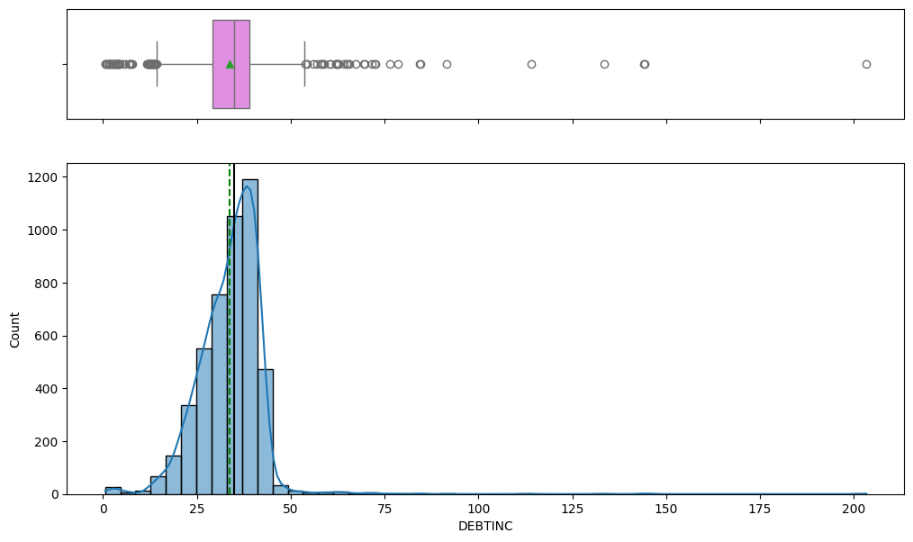

```python
histogram_boxplot(data, "DEBTINC")
```

### **Bivariate Analysis**

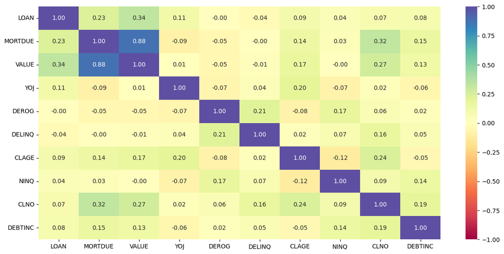

```python
# Exclude non-numeric columns
numeric_data = data.select_dtypes(include=np.number)

# Create heatmap
plt.figure(figsize=(15, 7))
sns.heatmap(numeric_data.corr(), annot=True, vmin=-1, vmax=1, fmt=".2f", cmap="Spectral")
plt.show()
```

## Treating Missing Values

**Strategy for Handling Missing Values**

```python
data = data.dropna(subset=['MORTDUE'])
data['MORTDUE'] = data['MORTDUE'].fillna(data['MORTDUE'].mean())  # Replace NaN with mean
```

```python
data = data.dropna(subset=['VALUE'])
data['VALUE'] = data['VALUE'].fillna(data['VALUE'].mean())  # Replace NaN with mean
```

```python
data = data.dropna(subset=['YOJ'])
data['YOJ'] = data['YOJ'].fillna(data['YOJ'].median())  # Replace NaN with median
```

```python
data = data.dropna(subset=['DEROG'])
data['DEROG'] = data['DEROG'].fillna(data['DEROG'].median())  # Replace NaN with median
```

```python
data = data.dropna(subset=['DELINQ'])
data['DELINQ'] = data['DELINQ'].fillna(data['DELINQ'].median())  # Replace NaN with median
```

```python
data = data.dropna(subset=['CLAGE'])
data['CLAGE'] = data['CLAGE'].fillna(data['CLAGE'].mean())  # Replace NaN with mean
```

```python
data = data.dropna(subset=['NINQ'])
data['NINQ'] = data['NINQ'].fillna(data['NINQ'].median())  # Replace NaN with median
```

```python
data = data.dropna(subset=['CLNO'])
data['CLNO'] = data['CLNO'].fillna(data['CLNO'].mean())  # Replace NaN with mean
```

```python
data = data.dropna(subset=['DEBTINC'])
data['DEBTINC'] = data['DEBTINC'].fillna(data['DEBTINC'].mean())  # Replace NaN with mean
```

```python
data = data.dropna(subset=['REASON'])
data['REASON'] = data['REASON'].fillna(data['REASON'].mode())  # Replace NaN with mode
```

```python
data = data.dropna(subset=['JOB'])
data['JOB'] = data['JOB'].fillna(data['JOB'].mode())  # Replace NaN with mode
```

```python
#Perform ANOVA analysis LOAN#
from scipy.stats import f_oneway

categories = data['BAD'].unique()
grouped_data = [data[data['BAD'] == cat]['LOAN'] for cat in categories]

# Perform ANOVA
f_stat, p_value = f_oneway(*grouped_data)
print(f"F-statistic: {f_stat}, p-value: {p_value}")
```

```
F-statistic: 3.278961543225549, p-value: 0.07026254176602012
```

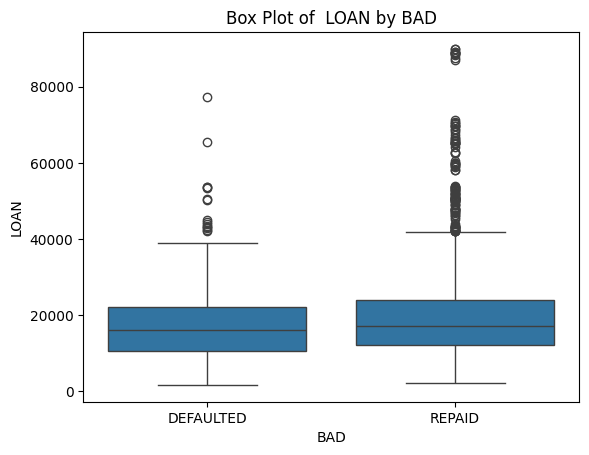

```python
# Create a box plot
sns.boxplot(x='BAD', y='LOAN', data=data)

# Show the plot
plt.title("Box Plot of  LOAN by BAD")
plt.show()
```

```python
#Perform ANOVA analysis VALUE#
from scipy.stats import f_oneway

categories = data['BAD'].unique()
grouped_data = [data[data['BAD'] == cat]['VALUE'] for cat in categories]

# Perform ANOVA
f_stat, p_value = f_oneway(*grouped_data)
print(f"F-statistic: {f_stat}, p-value: {p_value}")
```

```
F-statistic: 2.312036671989383, p-value: 0.12846978142784887
```

F-statistic: 2.31

This value suggests that the variance between the groups (based on the BAD categories) is not very large compared to the variance within the groups.

p-value: 0.128

Since this p-value is greater than the typical significance level of 0.05, we fail to reject the null hypothesis. This means there is not enough evidence to conclude that there are significant differences in the VALUE of loans across the different BAD categories.

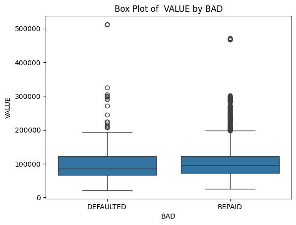

```python
# Create a box plot
sns.boxplot(x='BAD', y='VALUE', data=data)

# Show the plot
plt.title("Box Plot of  VALUE by BAD")
plt.show()
```

```python
#Perform ANOVA analysis MORTDUE#
from scipy.stats import f_oneway

categories = data['BAD'].unique()
grouped_data = [data[data['BAD'] == cat]['MORTDUE'] for cat in categories]

# Perform ANOVA
f_stat, p_value = f_oneway(*grouped_data)
print(f"F-statistic: {f_stat}, p-value: {p_value}")
```

```
F-statistic: 0.921380576669888, p-value: 0.337181764201573
```

- F-statistic: 0.92
- p-value: 0.337

The p-value exceeds 0.05, indicating no significant differences in loan values across the BAD categories.

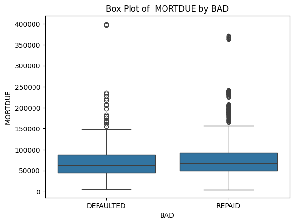

```python
# Create a box plot
sns.boxplot(x='BAD', y='MORTDUE', data=data)

# Show the plot
plt.title("Box Plot of  MORTDUE by BAD")
plt.show()
```

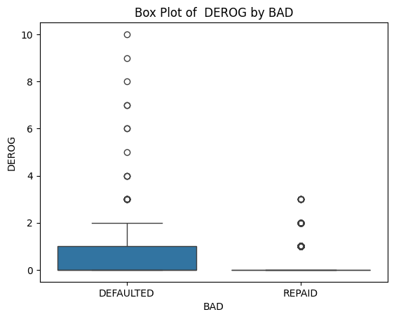

```python
# Create a box plot
sns.boxplot(x='BAD', y='DEROG', data=data)

# Show the plot
plt.title("Box Plot of  DEROG by BAD")
plt.show()
```

This can be interpreted as the likelihood that loan status (DEFAULTED or REPAID) changes based on the number of derogatory reports.

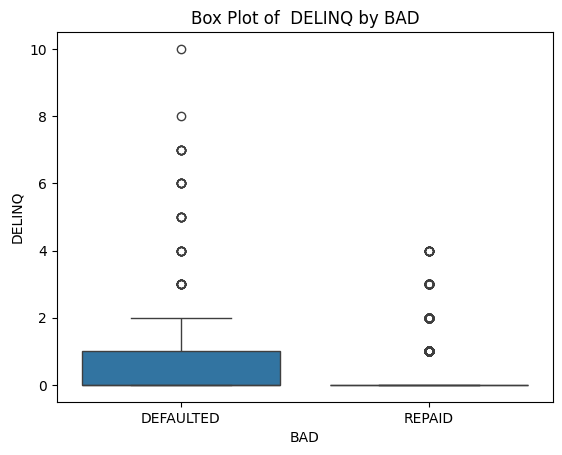

```python
#Create a box plot
sns.boxplot(x='BAD', y='DELINQ', data=data)

# Show the plot
plt.title("Box Plot of  DELINQ by BAD")
plt.show()
```

```python
#Perform ANOVA analysis CLAGE#
from scipy.stats import f_oneway

categories = data['BAD'].unique()
grouped_data = [data[data['BAD'] == cat]['CLAGE'] for cat in categories]

# Perform ANOVA
f_stat, p_value = f_oneway(*grouped_data)
print(f"F-statistic: {f_stat}, p-value: {p_value}")
```

```
F-statistic: 44.19372331442717, p-value: 3.457200818301408e-11
```

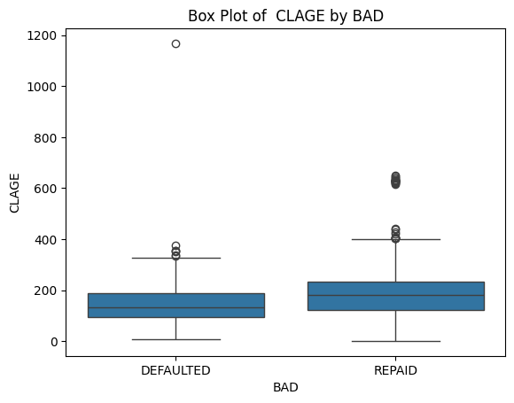

```python
#Create a box plot
sns.boxplot(x='BAD', y='CLAGE', data=data)

# Show the plot
plt.title("Box Plot of  CLAGE by BAD")
plt.show()
```

The results suggest that the age of the credit line (CLAGE) differs significantly between the categories of loans that are DEFAULTED and REPAID. This implies that the age of the credit line may be a factor in the likelihood of loan repayment.

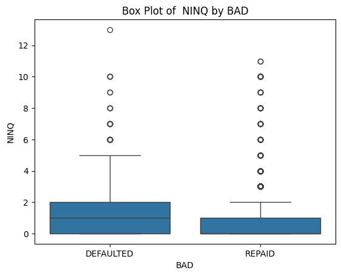

```python
#Create a box plot
sns.boxplot(x='BAD', y='NINQ', data=data)

# Show the plot
plt.title("Box Plot of  NINQ by BAD")
plt.show()
```

The grapgh shouws that people with higher NINQ tend to DEFAULT the loans more. With some outliers on both categories

```python
#Perform ANOVA analysis CLAGE#
from scipy.stats import f_oneway

categories = data['BAD'].unique()
grouped_data = [data[data['BAD'] == cat]['CLNO'] for cat in categories]

# Perform ANOVA
f_stat, p_value = f_oneway(*grouped_data)
print(f"F-statistic: {f_stat}, p-value: {p_value}")
```

```
F-statistic: 0.1906077917077655, p-value: 0.6624392742919463
```

The analysis suggests that the number of credit lines (CLNO) does not vary significantly between the different loan statuses. This could imply that having a certain number of credit lines is not strongly associated with whether a loan will be defaulted or repaid.

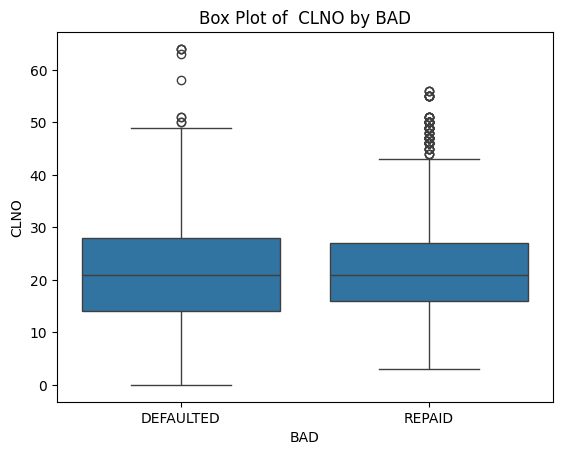

```python
#Create a box plot
sns.boxplot(x='BAD', y='CLNO', data=data)

# Show the plot
plt.title("Box Plot of  CLNO by BAD")
plt.show()
```

```python
#Perform ANOVA analysis CLAGE#
from scipy.stats import f_oneway

categories = data['BAD'].unique()
grouped_data = [data[data['BAD'] == cat]['DEBTINC'] for cat in categories]

# Perform ANOVA
f_stat, p_value = f_oneway(*grouped_data)
print(f"F-statistic: {f_stat}, p-value: {p_value}")
```

```
F-statistic: 166.0702200888723, p-value: 3.984168731049453e-37
```

The analysis suggests that the debt-to-income ratio (DEBTINC) significantly varies between the groups defined by loan status (defaulted vs. repaid). This implies that the debt-to-income ratio is associated with the likelihood of loan repayment or default, indicating that individuals with higher debt-to-income ratios are more likely to default on their loans.

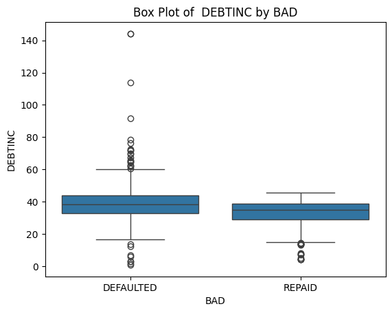

```python
#Create a box plot
sns.boxplot(x='BAD', y='DEBTINC', data=data)

# Show the plot
plt.title("Box Plot of  DEBTINC by BAD")
plt.show()
```

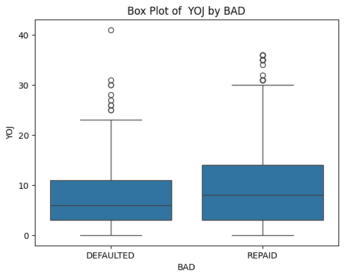

```python
#Create a box plot
sns.boxplot(x='BAD', y='YOJ', data=data)

# Show the plot
plt.title("Box Plot of  YOJ by BAD")
plt.show()
```

The graph shows that people with larger YOJ tend to repaid the loans more.

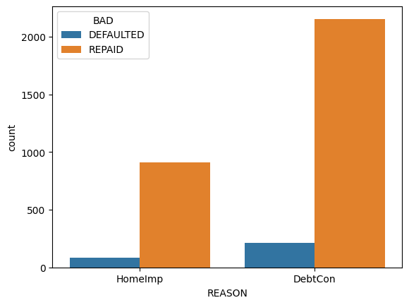

```python
#Status vs current_occupation#
sns.countplot(x='REASON', hue='BAD', data=data)
plt.show()
```

The reason for the loan does not appear to have a significant impact on whether the loan is defaulted or not. This suggests that factors other than the loan's purpose—such as financial standing, credit history, or debt-to-income ratio—are likely more influential in determining loan default risk.

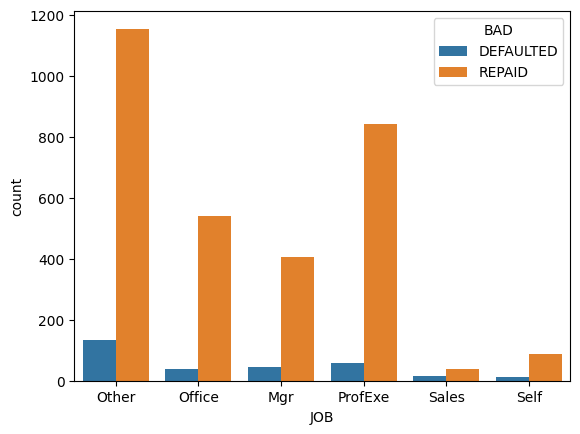

```python
#Status vs current_occupation#
sns.countplot(x='JOB', hue='BAD', data=data)
plt.show()
```

The JOB for the loan does not appear to have a significant impact on whether the loan is defaulted or not.

### **Multivariate Analysis**

Feature engineering

```python
target_column = 'BAD'

# Separate the target column
X = data.drop(columns=[target_column])
y = data[target_column]

# Apply one-hot encoding, dropping the first category for each encoded column
X_encoded = pd.get_dummies(X, drop_first=True)

# Concatenate the encoded features with the target column
data_encoded = pd.concat([X_encoded, y], axis=1)

#Convert the Status Column into Converted, Lost#
data_encoded['BAD'] = data['BAD'].map({'DEFAULTED': 1, 'REPAID': 0})
data_encoded.head()
```

|  | LOAN | MORTDUE | VALUE | YOJ | DEROG | DELINQ | CLAGE | NINQ | CLNO | DEBTINC | REASON_HomeImp | JOB_Office | JOB_Other | JOB_ProfExe | JOB_Sales | JOB_Self | BAD |
| --- | --- | --- | --- | --- | --- | --- | --- | --- | --- | --- | --- | --- | --- | --- | --- | --- | --- |
| 5 | 1700 | 30548.0 | 40320.0 | 9.0 | 0.0 | 0.0 | 101.466002 | 1.0 | 8.0 | 37.113614 | True | False | True | False | False | False | 1 |
| 7 | 1800 | 28502.0 | 43034.0 | 11.0 | 0.0 | 0.0 | 88.766030 | 0.0 | 8.0 | 36.884894 | True | False | True | False | False | False | 1 |
| 19 | 2300 | 102370.0 | 120953.0 | 2.0 | 0.0 | 0.0 | 90.992533 | 0.0 | 13.0 | 31.588503 | True | True | False | False | False | False | 0 |
| 25 | 2400 | 34863.0 | 47471.0 | 12.0 | 0.0 | 0.0 | 70.491080 | 1.0 | 21.0 | 38.263601 | True | False | False | False | False | False | 1 |
| 26 | 2400 | 98449.0 | 117195.0 | 4.0 | 0.0 | 0.0 | 93.811775 | 0.0 | 13.0 | 29.681827 | True | True | False | False | False | False | 0 |

```python
#Data Standardization#
scaler = StandardScaler()
df_scaled = scaler.fit_transform(data_encoded)
df_scaled = pd.DataFrame(df_scaled, columns=data_encoded.columns)
df_scaled.head()
```

|  | LOAN | MORTDUE | VALUE | YOJ | DEROG | DELINQ | CLAGE | NINQ | CLNO | DEBTINC | REASON_HomeImp | JOB_Office | JOB_Other | JOB_ProfExe | JOB_Sales | JOB_Self | BAD |
| --- | --- | --- | --- | --- | --- | --- | --- | --- | --- | --- | --- | --- | --- | --- | --- | --- | --- |
| 0 | -1.605179 | -1.013594 | -1.227728 | -0.014520 | -0.253434 | -0.344449 | -0.960979 | -0.024172 | -1.503755 | 0.374601 | 1.543018 | -0.455008 | 1.271166 | -0.603909 | -0.12652 | -0.174131 | 3.195831 |
| 1 | -1.595983 | -1.058972 | -1.178130 | 0.248797 | -0.253434 | -0.344449 | -1.114440 | -0.669522 | -1.503755 | 0.345832 | 1.543018 | -0.455008 | 1.271166 | -0.603909 | -0.12652 | -0.174131 | 3.195831 |
| 2 | -1.550001 | 0.579311 | 0.245826 | -0.936129 | -0.253434 | -0.344449 | -1.087536 | -0.669522 | -0.971043 | -0.320362 | 1.543018 | 2.197762 | -0.786679 | -0.603909 | -0.12652 | -0.174131 | -0.312908 |
| 3 | -1.540804 | -0.917894 | -1.097044 | 0.380455 | -0.253434 | -0.344449 | -1.335266 | -0.024172 | -0.118704 | 0.519249 | 1.543018 | -0.455008 | -0.786679 | -0.603909 | -0.12652 | -0.174131 | 3.195831 |
| 4 | -1.540804 | 0.492349 | 0.177149 | -0.672812 | -0.253434 | -0.344449 | -1.053469 | -0.669522 | -0.971043 | -0.560188 | 1.543018 | 2.197762 | -0.786679 | -0.603909 | -0.12652 | -0.174131 | -0.312908 |

```python
#Perform PCA#
pca = PCA(n_components=0.95)  # Retain 95% of the variance
# Fit and transform the scaled data
principal_components = pca.fit_transform(df_scaled)

# Convert the result back into a DataFrame for better readability
df_pca = pd.DataFrame(principal_components)

# Add column names for PCA components
df_pca.columns = [f'PC{i+1}' for i in range(df_pca.shape[1])]

# View the first few rows of the PCA-transformed data
print(df_pca.head())
```

```
        PC1       PC2       PC3       PC4       PC5       PC6       PC7  \
0 -2.878832  1.227112 -0.407946 -1.000862 -0.561634  2.250441 -0.020585
1 -2.916181  0.952754 -0.428108 -1.087492 -0.452377  2.400858  0.029653
2 -0.544619 -0.932651 -1.289837  2.184315  0.038239  2.041877 -0.227467
3 -1.794050  1.175201 -1.534680 -0.452049 -0.235527  1.814661  0.025751
4 -0.652885 -1.093552 -1.299318  2.048964  0.152008  1.940312 -0.232484

        PC8       PC9      PC10      PC11      PC12      PC13      PC14
0 -0.833289  0.058215  1.392226 -0.506119  0.426912  1.100981  1.529338
1 -1.075154  0.406623  1.351265 -0.364186  0.163929  0.881300  1.754150
2 -0.526354 -0.836751  0.456425  1.216387  0.511392 -0.026999  0.130991
3 -0.565156 -0.080849  1.481742 -1.157406  0.190616  0.085382  2.105970
4 -0.384708 -0.758087  0.491901  1.260661  0.603255 -0.111276  0.253122
```

```
[0.1564765  0.10449544 0.08437482 0.07753044 0.07239254 0.0664958
 0.06202289 0.05586553 0.05450037 0.05258649 0.04873911 0.04104201
 0.03975645 0.0354733 ]
```

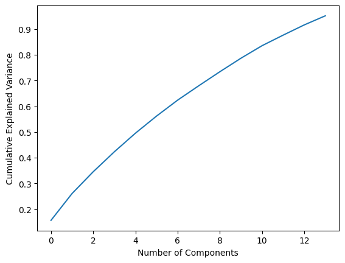

```python
# Get explained variance for each principal component
explained_variance = pca.explained_variance_ratio_
print(explained_variance)

# Plot cumulative explained variance
plt.plot(np.cumsum(explained_variance))
plt.xlabel('Number of Components')
plt.ylabel('Cumulative Explained Variance')
plt.show()
```

**Outliers Detection**

```python
#We will perform DBSCAN Clustering#
#Analyze to chose the correct epsilon#
#min samples = data size +1#



# Set k
min_samples = 16
k = min_samples + 1  # This is a common choice

# Fit Nearest Neighbors model
nbrs = NearestNeighbors(n_neighbors=k).fit(df_scaled)

# Get distances to the k-th nearest neighbor
distances, indices = nbrs.kneighbors(df_scaled)

# Sort the distances
distances = np.sort(distances[:, k-1], axis=0)
```

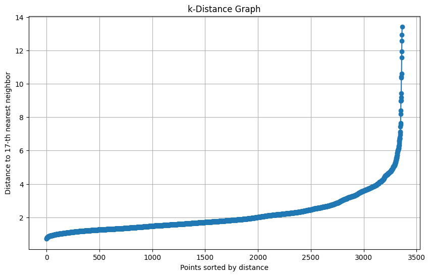

```python
#Plot K-Distance#
plt.figure(figsize=(10, 6))
plt.plot(distances, marker='o')
plt.title('k-Distance Graph')
plt.xlabel('Points sorted by distance')
plt.ylabel('Distance to {}-th nearest neighbor'.format(k))
plt.grid()
plt.show()
```

epsilon would be 4.5

```python
dbscan = DBSCAN(eps=4.5, min_samples=16)  # Adjust parameters as needed
dbscan.fit(df_scaled)
clusters = dbscan.fit_predict(df_scaled)
```

```python
# Count the number of points in each cluster
unique, counts = np.unique(clusters, return_counts=True)
cluster_counts = dict(zip(unique, counts))
print("Cluster counts:", cluster_counts)

# Extract outliers
outliers = df_scaled[clusters == -1]
print(f"Number of outliers detected: {len(outliers)}")
```

```
Cluster counts: {-1: 68, 0: 3162, 1: 49, 2: 85}
Number of outliers detected: 68
```

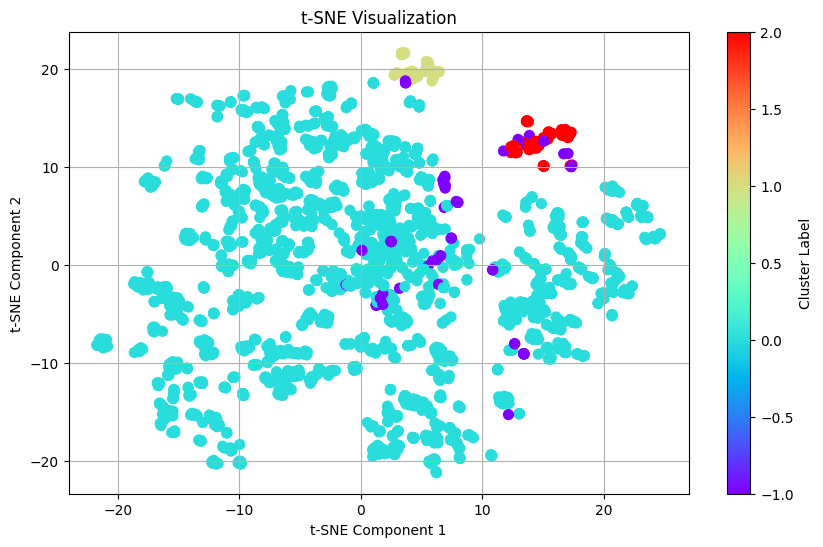

```python
# Scaled high-dimensional data
tsne = TSNE(n_components=3, random_state=42)
tsne_result = tsne.fit_transform(df_scaled)

# Visualize the result
plt.figure(figsize=(10, 6))
plt.scatter(tsne_result[:, 0], tsne_result[:, 1], c=clusters, cmap='rainbow', s=50)
plt.title('t-SNE Visualization')
plt.xlabel('t-SNE Component 1')
plt.ylabel('t-SNE Component 2')
plt.colorbar(label='Cluster Label')
plt.grid()
plt.show()
```

```python
df1 = data_encoded.copy()
df1 = pd.get_dummies(df1, columns=['BAD'], drop_first=True)
df1['Cluster'] = clusters
df1.head()
```

|  | LOAN | MORTDUE | VALUE | YOJ | DEROG | DELINQ | CLAGE | NINQ | CLNO | DEBTINC | REASON_HomeImp | JOB_Office | JOB_Other | JOB_ProfExe | JOB_Sales | JOB_Self | BAD_1 | Cluster |
| --- | --- | --- | --- | --- | --- | --- | --- | --- | --- | --- | --- | --- | --- | --- | --- | --- | --- | --- |
| 5 | 1700 | 30548.0 | 40320.0 | 9.0 | 0.0 | 0.0 | 101.466002 | 1.0 | 8.0 | 37.113614 | True | False | True | False | False | False | True | 0 |
| 7 | 1800 | 28502.0 | 43034.0 | 11.0 | 0.0 | 0.0 | 88.766030 | 0.0 | 8.0 | 36.884894 | True | False | True | False | False | False | True | 0 |
| 19 | 2300 | 102370.0 | 120953.0 | 2.0 | 0.0 | 0.0 | 90.992533 | 0.0 | 13.0 | 31.588503 | True | True | False | False | False | False | False | 0 |
| 25 | 2400 | 34863.0 | 47471.0 | 12.0 | 0.0 | 0.0 | 70.491080 | 1.0 | 21.0 | 38.263601 | True | False | False | False | False | False | True | 0 |
| 26 | 2400 | 98449.0 | 117195.0 | 4.0 | 0.0 | 0.0 | 93.811775 | 0.0 | 13.0 | 29.681827 | True | True | False | False | False | False | False | 0 |

```python
#Cluster Profiling# #Numerical#
numerical_vars = df1.select_dtypes(include=['int64', 'float64']).columns.tolist()
cluster_groups = df1.groupby('Cluster')
numerical_summary = cluster_groups[numerical_vars].agg(['count','mean','std'])
print("Numerical Summary:")
print(numerical_summary)
```

```
Numerical Summary:
         LOAN                             MORTDUE                 \
        count          mean           std   count           mean
Cluster
-1         68  31894.117647  18824.530537      68  126613.058824
 0       3162  18651.359899  10136.408440    3162   74219.894371
 1         49  13822.448980   7566.738215      49   67582.877551
 2         85  30749.411765  16119.853358      85  116460.847059

                       VALUE                                 YOJ            \
                   std count           mean            std count      mean
Cluster
-1       117860.224761    68  180103.602941  146071.469070    68  6.588235
 0        40202.262054  3162  104432.357052   48760.726278  3162  9.293801
 1        34202.749185    49   96570.877551   41178.065878    49  6.285714
 2        70425.238376    85  169888.600000   61847.111343    85  5.929412

                  DEROG                     DELINQ                     CLAGE  \
              std count      mean       std  count      mean       std count
Cluster
-1       4.719712    68  1.794118  2.458970     68  1.647059  2.635944    68
 0       7.707564  3162  0.110689  0.401381   3162  0.258697  0.709761  3162
 1       6.626965    49  0.265306  0.604687     49  0.000000  0.000000    49
 2       3.265214    85  0.105882  0.309513     85  0.094118  0.365915    85

                                 NINQ                      CLNO             \
               mean         std count      mean       std count       mean
Cluster
-1       207.022063  141.778505    68  3.338235  2.995570    68  25.308824
 0       179.260489   81.436564  3162  0.995572  1.484491  3162  21.847249
 1       199.902169   91.126435    49  0.306122  0.547878    49  25.571429
 2       213.745653   44.449637    85  1.176471  1.103851    85  27.494118

                   DEBTINC                       Cluster
               std   count       mean        std   count mean  std
Cluster
-1       14.723580      68  43.326476  24.803563      68 -1.0  0.0
 0        9.020193    3162  33.855506   7.137427    3162  0.0  0.0
 1       11.445523      49  35.696150   6.390693      49  1.0  0.0
 2       13.086365      85  36.296888   4.764370      85  2.0  0.0
```

```python
#Checking results for the categorical variables#
categorical_vars = df1.select_dtypes(include=['bool']).columns.tolist()
cluster_groups = df1.groupby('Cluster')[categorical_vars].sum()
cluster_groups.style.highlight_max(color = "lightgreen", axis = 0)
```

| Cluster | REASON_HomeImp | JOB_Office | JOB_Other | JOB_ProfExe | JOB_Sales | JOB_Self | BAD_1 |
| --- | --- | --- | --- | --- | --- | --- | --- |
| -1 | 30 | 4 | 14 | 24 | 4 | 14 | 50 |
| 0 | 908 | 573 | 1272 | 875 | 0 | 0 | 236 |
| 1 | 8 | 0 | 0 | 0 | 49 | 0 | 10 |
| 2 | 49 | 0 | 0 | 0 | 0 | 85 | 4 |

## Treating Outliers

it would be reasonable to consider removing the -1 cluster if it represents an outlier or noise, as indicated by its characteristics that are quite different from the other clusters. Since it has higher means for several features like LOAN, MORTDUE, VALUE, and DEBTINC, this suggests that it may be an anomaly compared to the other clusters. Removing it could help in focusing on more homogeneous groups.

```python
df1 = df1[df1['Cluster'] != -1]
```

## **Important Insights from EDA**

1. What is the range of values for the loan amount variable "LOAN"? The average loan amount is 18,607.97 with a wide standard deviation of 11,207.48, indicating considerable variation in loan amounts. The range is quite large, with the minimum loan at 1,100 and the maximum at 89,900, indicating the presence of loans of varying sizes. The 25th percentile (11,100), 50th percentile (16,300), and 75th percentile (23,300) show a moderate concentration in the middle values.
2. How does the distribution of years at present job "YOJ" vary across the dataset? The average years on the job is 8.92, with a standard deviation of 7.57. The minimum is 0 (likely people who recently started or have no job), while the maximum is 41 years. The 25th percentile (3 years) and 75th percentile (13 years) suggest that many people have moderate job tenure, though some outliers exist.
3. How many unique categories are there in the REASON variable? There are 2 Unique categories in the REASON varaible (DebCon and HomeImp)
4. What is the most common category in the JOB variable? The "Other" category represents more than 40% of the observations in the JOB varialble
5. Is there a relationship between the REASON variable and the proportion of applicants who defaulted on their loan? The reason for the loan does not appear to have a significant impact on whether the loan is defaulted or not. This suggests that factors other than the loan's purpose—such as financial standing, credit history, or debt-to-income ratio—are likely more influential in determining loan default risk.
6. Do applicants who default have a significantly different loan amount compared to those who repay their loan? There is not eveidence that there are significant difference between the loan amounts that were defaulted or repaid.
7. Is there a correlation between the value of the property and the loan default rate? The p-value exceeds 0.05, indicating no significant differences in loan values across the BAD categories.
8. Do applicants who default have a significantly different mortgage amount compared to those who repay their loan? There is not significant differences in the MORTDUE values between the repaid and defaulted loans.
9. MORTDUE and Loan Value show a slight correlation, which is expected as individuals with higher loan values typically have more to repay.
10. MORTDUE and Property VALUE are highly correlated, which makes sense because higher property values often indicate that individuals owe more. Loan Value and Property VALUE also exhibit a strong correlation, as people with larger loans are likely to purchase more expensive properties.
11. CLNO (number of credit lines) and MORTDUE show a strong correlation. This is expected since individuals with more credit lines tend to have higher amounts to repay.
12. An interesting correlation exists between NINQ (number of inquiries) and DEROG (derogatory reports), suggesting that individuals with more negative credit reports often seek additional loans.
13. The relationship between DELINQ (delinquent accounts) and DEROG is also strong, which is expected as those with more delinquencies typically have more derogatory reports.
14. Another notable correlation is between YOJ (years on the job) and CLAGE (credit line age). Individuals with more stable employment tend to have longer credit line histories.
15. The likelihood that loan status (DEFAULTED or REPAID) changes based on the number of derogatory reports.
16. The results suggest that the number of derogatory reports (DELINQ) varies significantly between the categories of loans that are either DEFAULTED or REPAID. This implies that the likelihood of having derogatory reports is associated with the loan status.
17. The results suggest that the age of the credit line (CLAGE) differs significantly between the categories of loans that are DEFAULTED and REPAID. This implies that the age of the credit line may be a factor in the likelihood of loan repayment.
18. The grapgh shouws that people with higher NINQ tend to DEFAULT the loans more. With some outliers on both categories
19. The analysis suggests that the number of credit lines (CLNO) does not vary significantly between the different loan statuses. This could imply that having a certain number of credit lines is not strongly associated with whether a loan will be defaulted or repaid.
20. The analysis suggests that the debt-to-income ratio (DEBTINC) significantly varies between the groups defined by loan status (defaulted vs. repaid). This implies that the debt-to-income ratio is associated with the likelihood of loan repayment or default, indicating that individuals with higher debt-to-income ratios are more likely to default on their loans.
21. The JOB for the loan does not appear to have a significant impact on whether the loan is defaulted or not

## **Model Building - Approach**

- Data preparation
- Partition the data into train and test set
- Build the model
- Fit on the train data
- Tune the model
- Test the model on test set

```python
# Separating the target variable and other variables
Y = df1.BAD_1

X = df1.drop(['BAD_1', 'Cluster'], axis=1)
X_train, X_test, y_train, y_test = train_test_split(X, Y, test_size=0.3, random_state=1)
```

### Logistic Regression

```python
model = LogisticRegression(max_iter=1000)  # Increase max_iter if you run into convergence issues
model.fit(X_train, y_train)
```

```
LogisticRegression(max_iter=1000)
```

```python
y_pred = model.predict(X_test)
```

```python
accuracy = accuracy_score(y_test, y_pred)
print(f"Accuracy: {accuracy}")
```

```
Accuracy: 0.9292214357937311
```

```python
cm = confusion_matrix(y_test, y_pred)
print(f"Confusion Matrix:\n{cm}")
```

```
Confusion Matrix:
[[915   7]
 [ 63   4]]
```

```python
report = classification_report(y_test, y_pred)
print(f"Classification Report:\n{report}")
```

```
Classification Report:
              precision    recall  f1-score   support

       False       0.94      0.99      0.96       922
        True       0.36      0.06      0.10        67

    accuracy                           0.93       989
   macro avg       0.65      0.53      0.53       989
weighted avg       0.90      0.93      0.90       989
```

The model performs well for non-defaulters (False) but poorly for defaulters (True):

Non-defaulters (False): High precision (0.94), recall (0.99), and f1-score (0.96). Defaulters (True): Low precision (0.36), recall (0.06), and f1-score (0.10). Accuracy: 93%, but this is skewed due to class imbalance (many more non-defaulters).

Key Issue: The model struggles with predicting defaulters, likely due to class imbalance.

```python
model = LogisticRegression(class_weight='balanced',max_iter=1000)  # Increase max_iter if you run into convergence issues
model.fit(X_train, y_train)
```

```
LogisticRegression(class_weight='balanced', max_iter=1000)
```

```python
report = classification_report(y_test, y_pred)
print(f"Classification Report:\n{report}")
```

```
Classification Report:
              precision    recall  f1-score   support

       False       0.94      0.99      0.96       922
        True       0.36      0.06      0.10        67

    accuracy                           0.93       989
   macro avg       0.65      0.53      0.53       989
weighted avg       0.90      0.93      0.90       989
```

While the overall accuracy remains high, the model still struggles to identify the minority class (defaults). The low precision and recall for the "True" class suggest the need for further improvements

### Decision Tree

```python
# Building decision tree model
dt = DecisionTreeClassifier( random_state = 42)
dt
```

```
DecisionTreeClassifier(random_state=42)
```

```python
# Fitting decision tree model
dt.fit(X_train, y_train)
```

```
DecisionTreeClassifier(random_state=42)
```

Model Performance evaluation and improvement

```python
def metrics_score(actual, predicted):

    print(classification_report(actual, predicted))

    cm = confusion_matrix(actual, predicted)

    plt.figure(figsize = (8, 5))

    sns.heatmap(cm, annot = True, fmt = '.2f', xticklabels = ['REPAID', 'DEFAULTED'], yticklabels = ['REPAID', 'DEFAULTED'])
    plt.ylabel('Actual')

    plt.xlabel('Predicted')

    plt.show()
```

```python
def model_performance_classification(model, predictors, target):
    """
    Function to compute different metrics to check classification model performance

    model: classifier

    predictors: independent variables

    target: dependent variable
    """

    # Predicting using the independent variables
    pred = model.predict(predictors)

    recall = recall_score(target, pred,average = 'macro')                 # To compute recall

    precision = precision_score(target, pred, average = 'macro')              # To compute precision

    acc = accuracy_score(target, pred)                                 # To compute accuracy score


    # Creating a dataframe of metrics

    df_perf = pd.DataFrame(
        {
            "Precision":  precision,
            "Recall":  recall,
            "Accuracy": acc,
        },

        index = [0],
    )

    return df_perf
```

```python
# Checking performance on the training dataset
y_train_pred_dt = dt.predict(X_train)

metrics_score(y_train, y_train_pred_dt)
```

```
              precision    recall  f1-score   support

       False       1.00      1.00      1.00      2124
        True       1.00      1.00      1.00       183

    accuracy                           1.00      2307
   macro avg       1.00      1.00      1.00      2307
weighted avg       1.00      1.00      1.00      2307
```

Observation:

The Decision tree is giving a 100% score for all metrics on the training dataset.

```
              precision    recall  f1-score   support

       False       0.97      0.97      0.97       922
        True       0.54      0.55      0.55        67

    accuracy                           0.94       989
   macro avg       0.76      0.76      0.76       989
weighted avg       0.94      0.94      0.94       989
```

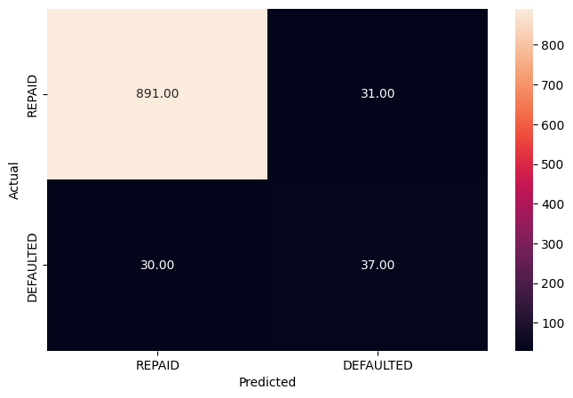

```python
# Checking performance on the test dataset
y_test_pred_dt = dt.predict(X_test)

metrics_score(y_test, y_test_pred_dt)
```

The Decision Tree model shows improved performance for the minority class (defaults) compared to the logistic regression model. While the precision and recall for the "True" class are still moderate, the balanced macro averages suggest better overall performance. The high accuracy and weighted averages indicate that the model is effectively identifying the majority class (repayments).

```python
dtree_test = model_performance_classification(dt,X_test,y_test)
dtree_test
```

|  | Precision | Recall | Accuracy |
| --- | --- | --- | --- |
| 0 | 0.755772 | 0.759308 | 0.938322 |

The model has room for improvement in identifying defaulters effectively. This is crucial as missing defaulters can lead to significant financial implications.

### **Decision Tree - Hyperparameter Tuning**

- Hyperparameter tuning is tricky in the sense that **there is no direct way to calculate how a change in the hyperparameter value will reduce the loss of your model**, so we usually resort to experimentation. We'll use Grid search to perform hyperparameter tuning.
- **Grid search is a tuning technique that attempts to compute the optimum values of hyperparameters.**
- **It is an exhaustive search** that is performed on the specific parameter values of a model.
- The parameters of the estimator/model used to apply these methods are **optimized by cross-validated grid-search** over a parameter grid.

**Criterion {“gini”, “entropy”}**

The function to measure the quality of a split. Supported criteria are “gini” for the Gini impurity and “entropy” for the information gain.

**max_depth**

The maximum depth of the tree. If None, then nodes are expanded until all leaves are pure or until all leaves contain less than min_samples_split samples.

**min_samples_leaf**

The minimum number of samples is required to be at a leaf node. A split point at any depth will only be considered if it leaves at least min_samples_leaf training samples in each of the left and right branches. This may have the effect of smoothing the model, especially in regression.

You can learn about more Hyperpapameters on this link and try to tune them.

https://scikit-learn.org/stable/modules/generated/sklearn.tree.DecisionTreeClassifier.html

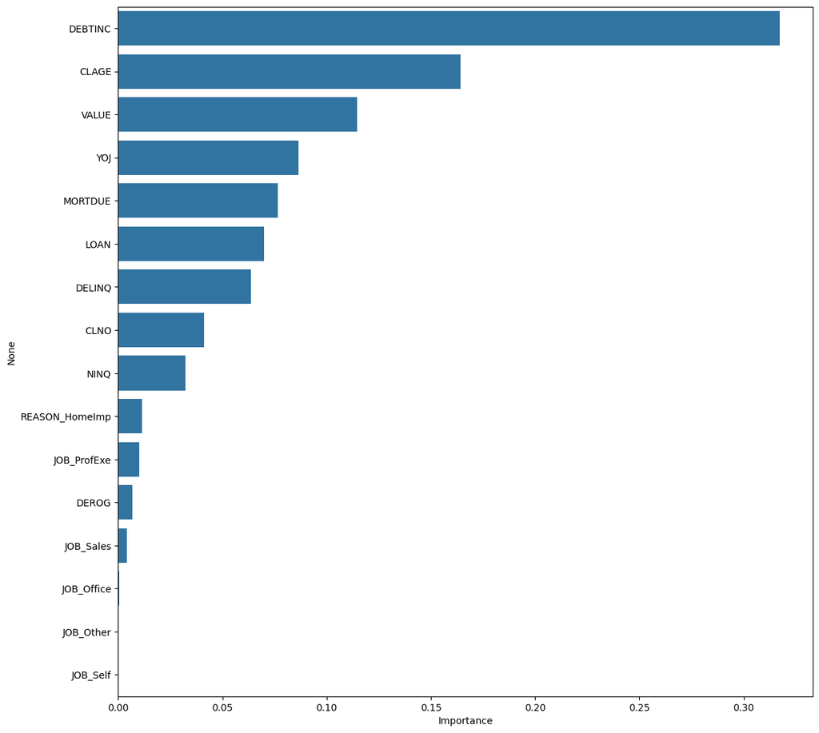

```python
# Plot the feature importance

importances = dt.feature_importances_

columns = X.columns

importance_df = pd.DataFrame(importances, index = columns, columns = ['Importance']).sort_values(by = 'Importance', ascending = False)

plt.figure(figsize = (13, 13))

sns.barplot(x=importance_df.Importance,y=importance_df.index);
```

The results from the Decision Tree suggest that DEBINC AND CLAGE, are the most important features in predicting DEFAULTER. This could signify the following:

The results from the Decision Tree suggest that DEBTINC (Debt-to-Income Ratio) and CLAGE (Age of Credit Line) are the most important features in predicting defaults. This could signify the following:

Debt-to-Income Ratio (DEBTINC):

A higher DEBTINC indicates that borrowers have a larger portion of their income going toward debt repayment, which can signal financial strain. This can lead to increased likelihood of default, as borrowers may struggle to meet their loan obligations.

Age of Credit Line (CLAGE):

A longer CLAGE typically suggests that the borrower has a more established credit history. This can be a positive indicator of creditworthiness, as it reflects the borrower’s ability to manage credit over time. Conversely, a shorter credit history may indicate a higher risk of default, especially for those with less experience in handling credit.

Implications: Risk Assessment: Lenders may want to closely monitor these two features when assessing the risk of loan defaults. Higher debt-to-income ratios may warrant more scrutiny, and applicants with shorter credit histories might be considered riskier.

Credit Policy: Lenders could consider implementing stricter criteria for borrowers with high DEBTINC or low CLAGE to mitigate potential defaults.

**Tunning the model**

```python
# Choose the type of classifier
dtree_estimator = DecisionTreeClassifier(random_state = 1)

# Grid of parameters to choose from
parameters = {'max_depth': np.arange(2, 7),
              'criterion': ['gini', 'entropy'],
              'min_samples_leaf': [5, 10, 20, 25]
             }

# Type of scoring used to compare parameter combinations
scorer = metrics.make_scorer(recall_score, pos_label = 1)

# Run the grid search
gridCV = GridSearchCV(dtree_estimator, parameters, scoring = scorer, cv = 10)

# Fitting the grid search on the train data
gridCV = gridCV.fit(X_train, y_train)

# Set the classifier to the best combination of parameters
dtree_estimator = gridCV.best_estimator_

# Fit the best estimator to the data
dtree_estimator.fit(X_train, y_train)
```

```
DecisionTreeClassifier(max_depth=6, min_samples_leaf=5, random_state=1)
```

```
              precision    recall  f1-score   support

       False       0.95      1.00      0.97      2124
        True       0.94      0.43      0.59       183

    accuracy                           0.95      2307
   macro avg       0.95      0.71      0.78      2307
weighted avg       0.95      0.95      0.94      2307
```

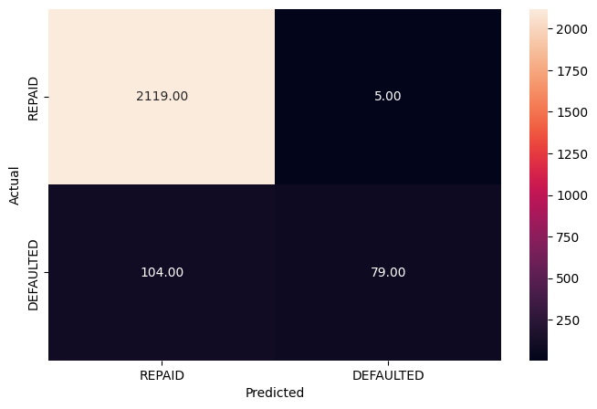

```python
# Checking performance on the training dataset
y_train_pred_dt = dtree_estimator.predict(X_train)

metrics_score(y_train, y_train_pred_dt)
```

In comparison to the model with default values of hyperparameters, the performance on the training set has gone down significantly. This makes sense because we are trying to reduce overfitting.

```
              precision    recall  f1-score   support

       False       0.95      0.99      0.97       922
        True       0.71      0.33      0.45        67

    accuracy                           0.95       989
   macro avg       0.83      0.66      0.71       989
weighted avg       0.94      0.95      0.94       989
```

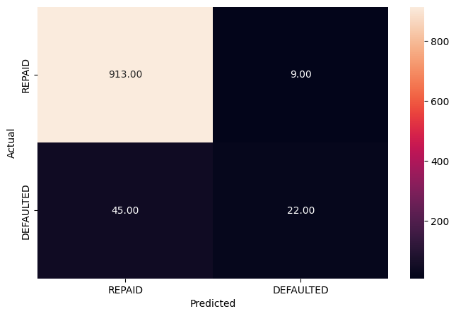

```python
# Checking performance on the test dataset
y_test_pred_dt = dtree_estimator.predict(X_test)

metrics_score(y_test, y_test_pred_dt)
```

The model performs well in predicting non-defaulters but struggles to identify defaulters effectively, as indicated by the low recall for the True class.

Observations:

The tuned model is performing BAD in comparison to the model with default values of hyperparameters. This model is not overfitting the training data and giving a bad recall on the test and train datasets.

### **Building a Random Forest Classifier**

**Random Forest is a bagging algorithm where the base models are Decision Trees.** Samples are taken from the training data and on each sample a decision tree makes a prediction.

**The results from all the decision trees are combined together and the final prediction is made using voting or averaging.**

```python
# Fitting the Random Forest classifier on the training data
rf_estimator = RandomForestClassifier( random_state = 1)

rf_estimator.fit(X_train, y_train)
```

```
RandomForestClassifier(random_state=1)
```

```python
# Checking performance on the training data
y_pred_train_rf = rf_estimator.predict(X_train)

metrics_score(y_train, y_pred_train_rf)
```

```
              precision    recall  f1-score   support

       False       1.00      1.00      1.00      2124
        True       1.00      1.00      1.00       183

    accuracy                           1.00      2307
   macro avg       1.00      1.00      1.00      2307
weighted avg       1.00      1.00      1.00      2307
```

Observation:

The Random Forest is giving a 100% score for all metrics on the training dataset.

```python
rf_estimator_test = model_performance_classification(rf_estimator,X_test,y_test)
rf_estimator_test
```

|  | Precision | Recall | Accuracy |
| --- | --- | --- | --- |
| 0 | 0.942954 | 0.692945 | 0.956522 |

Accuracy: 0.957 (95.7% overall accuracy)

Interpretation: High precision indicates low false positives, but recall for defaulters is lower, suggesting missed defaulters.

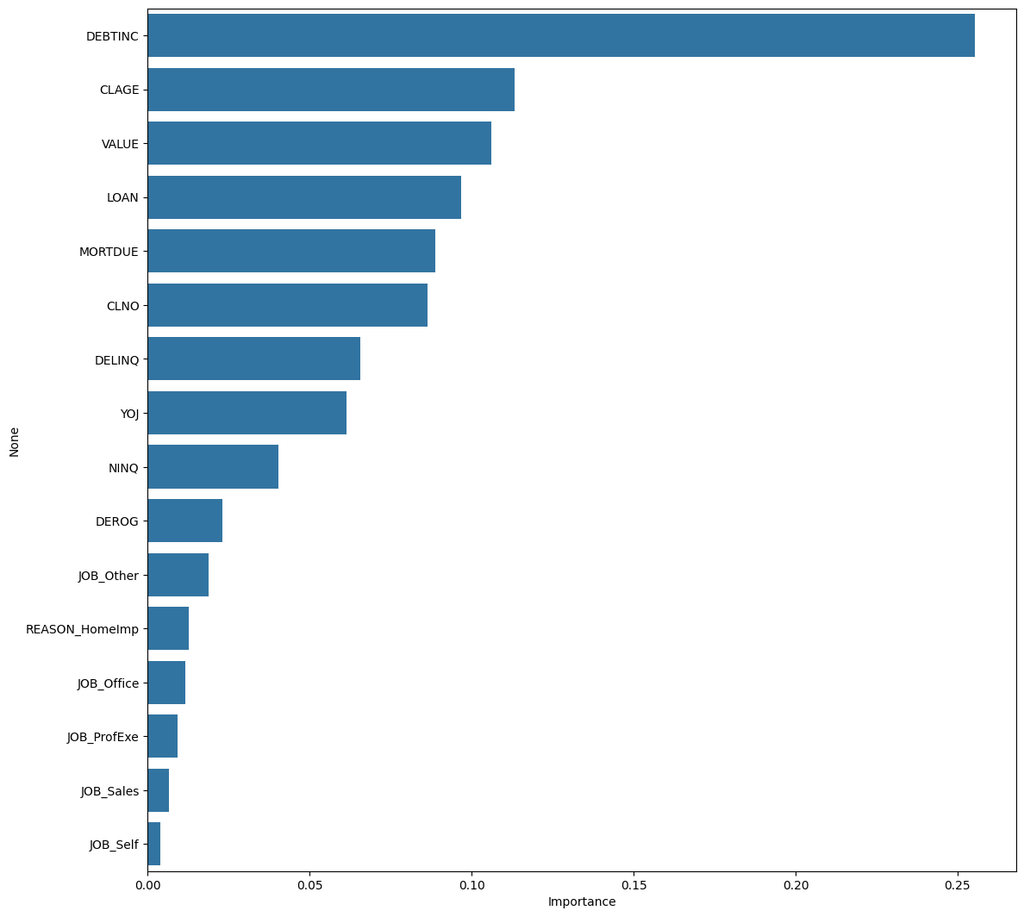

```python
# Plotting feature importance
importances = rf_estimator.feature_importances_

columns = X.columns

importance_df = pd.DataFrame(importances, index = columns, columns = ['Importance']).sort_values(by = 'Importance', ascending = False)

plt.figure(figsize = (13, 13))

sns.barplot(x= importance_df.Importance, y=importance_df.index);
```

### **Random Forest Classifier Hyperparameter Tuning**

```python
# Choose the type of classifier
rf_estimator_tuned = RandomForestClassifier( random_state = 1)

# Grid of parameters to choose from
params_rf = {
        "n_estimators": [100, 250, 500],
        "min_samples_leaf": np.arange(1, 4, 1),
        "max_features": [0.7, 0.9, 'auto'],
}


# Type of scoring used to compare parameter combinations - recall score for class 1
scorer = metrics.make_scorer(recall_score, pos_label = 1)

# Run the grid search
grid_obj = GridSearchCV(rf_estimator_tuned, params_rf, scoring = scorer, cv = 5)

grid_obj = grid_obj.fit(X_train, y_train)

# Set the classifier to the best combination of parameters
rf_estimator_tuned = grid_obj.best_estimator_
```

```python
rf_estimator_tuned.fit(X_train, y_train)
```

```
RandomForestClassifier(max_features=0.7, random_state=1)
```

```python
# Checking performance on the training data
y_pred_train_rf_tuned = rf_estimator_tuned.predict(X_train)

metrics_score(y_train, y_pred_train_rf_tuned)
```

```
              precision    recall  f1-score   support

       False       1.00      1.00      1.00      2124
        True       1.00      1.00      1.00       183

    accuracy                           1.00      2307
   macro avg       1.00      1.00      1.00      2307
weighted avg       1.00      1.00      1.00      2307
```

```
              precision    recall  f1-score   support

       False       0.96      1.00      0.98       922
        True       0.87      0.40      0.55        67

    accuracy                           0.96       989
   macro avg       0.91      0.70      0.76       989
weighted avg       0.95      0.96      0.95       989
```

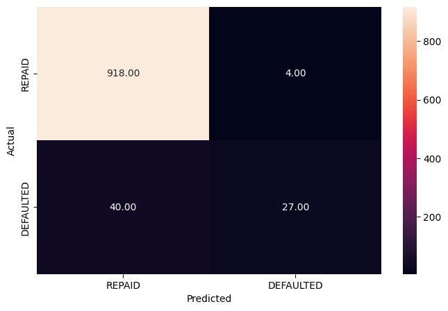

```python
#Checking performance on the test data
y_pred_test_rf_tuned = rf_estimator_tuned.predict(X_test)

metrics_score(y_test, y_pred_test_rf_tuned)
```

```python
rf_estimator_tuned_test = model_performance_classification(rf_estimator_tuned, X_test, y_test)
rf_estimator_tuned_test
```

|  | Precision | Recall | Accuracy |
| --- | --- | --- | --- |
| 0 | 0.914607 | 0.699323 | 0.955511 |

The tuned model maintains a high overall accuracy with slightly improved recall for defaulters compared to the untuned model. However, precision for non-defaulters has decreased, indicating a higher false positive rate.

Scope for Improvement

Hyperparameter Tuning: Continue optimizing parameters, especially in Random Forest and Decision Trees, to boost recall without sacrificing precision.

Feature Engineering: Explore new features or transformations of existing features to capture more informative patterns.

Model Stacking: Consider ensemble methods that combine predictions from multiple models to improve overall performance.

Cross-Validation: Ensure robustness of performance across different datasets by implementing k-fold cross-validation

**2. Refined insights:**

Key Predictors of Default:

Potential for Enhanced Prediction:

There is room for further improvements through advanced techniques such as hyperparameter tuning, feature engineering, and exploring ensemble learning methods. Implementing these strategies could lead to better identification of at-risk borrowers.

**Recommendations**

Focus on refining the Random Forest model to maximize recall while maintaining precision.

Investigate additional features or data transformations that could provide deeper insights into borrower behavior.

**Executive Summary**

- Problem Summary: The primary goal is to predict loan defaults among applicants. High default rates can significantly impact financial institutions' profitability and operational efficiency. Understanding the factors leading to defaults enables better risk management strategies, allowing lenders to make more informed decisions on loan approvals and terms.
- Final Proposed Solution Design: To address this problem, we have evaluated several machine learning models, including:
  - Logistic Regression: Offers a baseline for understanding the relationship between predictor variables and the likelihood of default.
  - Decision Tree: Provides interpretability by visualizing decision-making processes based on feature importance.
  - Random Forest: An ensemble method that enhances predictive accuracy by aggregating predictions from multiple decision trees.

**Problem and Solution Summary**

Key Points of Proposed Solution Design:

- Model Selection:

  Emphasis is placed on evaluating models based on accuracy, precision, recall, and F1-score. These metrics provide a comprehensive understanding of model performance, particularly regarding the identification of defaulters. Feature Importance:

  Key features such as DEBTINC (debt-to-income ratio) and CLAGE (age of credit line) are highlighted as significant predictors of loan default. This insight can guide the financial institution's lending strategies and criteria.
- Impact on Business:

  Implementing the Tuned Random Forest model will improve predictive accuracy, resulting in:
  - Lower Default Rates: Enhanced ability to identify at-risk applicants allows for more informed lending decisions, potentially leading to a decrease in loan defaults.
  - Optimized Resource Allocation: Better prediction capabilities enable the allocation of resources to manage higher-risk loans effectively.
  - Improved Risk Management: By understanding the predictors of default, the financial institution can implement targeted strategies to mitigate risks.
- Recommendations for Implementation
  - Key Recommendations:
    - Model Deployment:

    Integrate the Tuned Random Forest Classifier into the loan approval process. This model should be used to evaluate applicants in real-time, providing predictions on default likelihood based on the input features.
    - Continuous Monitoring and Refinement:

      Establish an ongoing system for model evaluation. Regularly monitor model performance against new data to ensure its predictions remain accurate over time. Plan for periodic retraining to adapt to evolving applicant behaviors and economic conditions.
  - Key Actionables for Stakeholders:
    - Data Engineering Teams:

      Ensure that high-quality, relevant data is readily available for the model. This includes maintaining data pipelines and addressing any issues with data quality or completeness.
    - Risk Management Teams:

      Collaborate closely with data scientists to understand model outputs. Use insights from the model to inform risk mitigation strategies and adjust lending criteria as necessary. Expected Benefits and Costs:
- Benefits:
  - Improved predictive accuracy leads to reduced default rates, resulting in enhanced profitability and operational efficiency.
  - Better decision-making processes foster trust and satisfaction among stakeholders, including applicants and investors.
- Cost Estimates:
  - Initial costs may involve investments in data infrastructure, model development, and personnel training. Ongoing costs for model maintenance, monitoring, and updates are expected to represent around 10-15% of the financial institution's operational expenses.
- Key Risks and Challenges:
  - Model Overfitting:
    - There is a risk that the model may perform well on training data but poorly on unseen data. Regular validation against new data sets is crucial to avoid overfitting.
  - Data Quality:
    - Ensuring high-quality input data is paramount. Inaccurate or outdated data can lead to misleading predictions, impacting the model's effectiveness.
  - Further Analysis:
    - Conduct exploratory analyses to examine the influence of additional features or external economic indicators on loan defaults. This may involve incorporating demographic information or macroeconomic data.
    - Consider building ensemble models or exploring advanced techniques like neural networks if the current model's performance does not meet expectations in future evaluations.